# Clustering

## 3.5 Índice de Davies-Bouldin

Compara la dispersión dentro de los grupos con la separación entre grupos. A diferencia de otros índices, aquí un valor más bajo indica un mejor clustering.

**Mostrar código**

```r
DB_index <- clusterSim::index.DB(dades[, varNum], clustering$cluster)
DB_index
```

```
$DB
[1] 1.44675

$r
[1] 1.644086 1.052079 1.644086

$R
         [,1]     [,2]     [,3]
[1,]      Inf 1.052079 1.644086
[2,] 1.052079      Inf 1.024064
[3,] 1.644086 1.024064      Inf

$d
         1        2        3
1  0.00000 42.29705 25.61027
2 42.29705  0.00000 43.65562
3 25.61027 43.65562  0.00000

$S
[1] 20.94957 23.55025 21.15591

$centers
         [,1]     [,2]     [,3]     [,4]
[1,] 48.18208 41.71973 3.717541 37.65682
[2,] 43.72352 81.91918 3.782219 25.28094
[3,] 40.57143 40.07001 3.727342 13.25922
```

**Mostrar código**

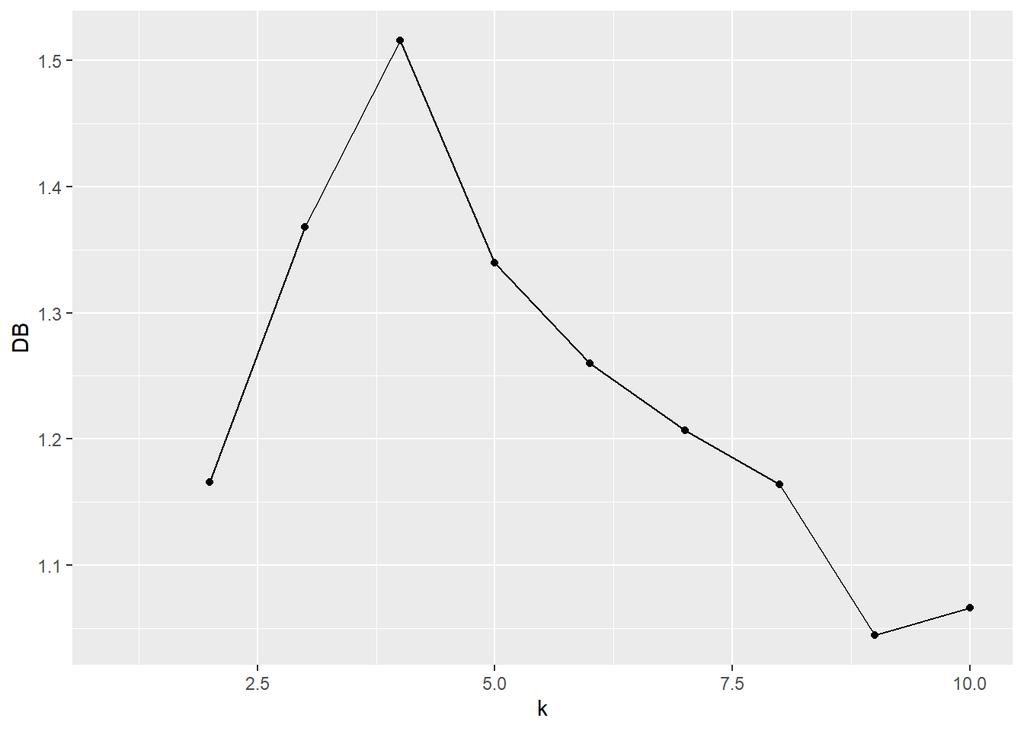

```r
DB_indexes <- vector()
for (k in 1:10) {
  kmeans_result <- kmeans(dades[, varNum], centers = k)
  DB_index <- clusterSim::index.DB(dades[, varNum], kmeans_result$cluster)
  DB_indexes[k] <- DB_index$DB
}

DB_df <- data.frame(k = 1:10, DB = DB_indexes)
ggplot(DB_df, aes(x = k, y = DB)) + geom_point() + geom_line()
```

En el gráfico, interesa buscar valores pequeños del índice. Si además se observa un cambio de pendiente claro, ese punto puede servir como referencia para fijar (k).

## 3.6 Índice de Calinski-Harabasz

Mide la relación entre dispersión intra-cluster y dispersión inter-cluster. Cuanto mayor sea el índice, mejor separación relativa existe entre grupos.

**Mostrar código**

```r
CH_index <- fpc::calinhara(dades[, varNum], clustering$cluster)
CH_index
```

```
[1] 1996.947
```

**Mostrar código**

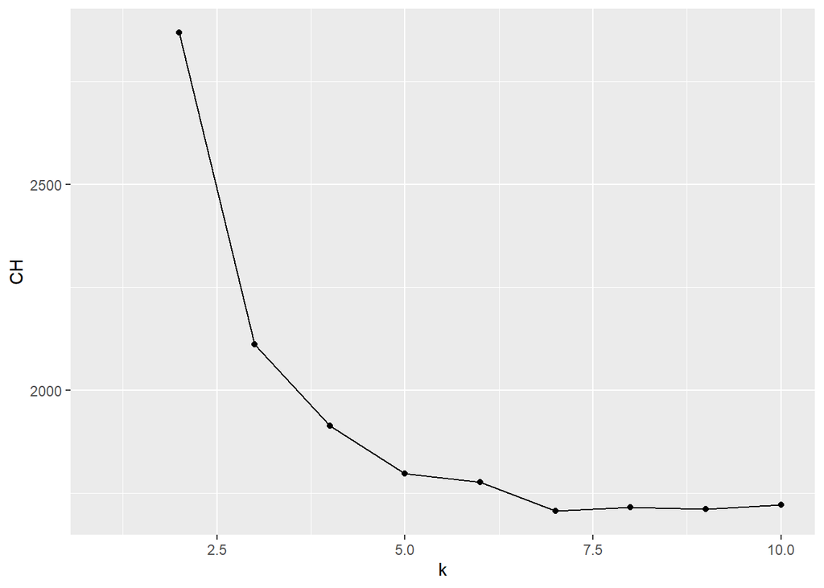

```r
CH_indexes <- vector()
for (k in 1:10) {
  kmeans_result <- kmeans(dades[, varNum], centers = k)
  CH_index <- calinhara(dades[, varNum], kmeans_result$cluster)
  CH_indexes[k] <- CH_index
}

CH_df <- data.frame(k = 1:10, CH = CH_indexes)
ggplot(CH_df, aes(x = k, y = CH)) + geom_point() + geom_line()
```

En este caso, el valor óptimo de (k) suele asociarse al máximo del índice o a una zona claramente dominante frente a los valores vecinos.

## 3.7 Entropía

La entropía puede interpretarse como una medida de pureza o heterogeneidad de la partición. Valores medios bajos sugieren grupos más homogéneos.

**Mostrar código**

```r
cluster_labels <- clustering$cluster

cluster_entropy <- entropy::entropy(table(cluster_labels))
cluster_entropy <- sapply(unique(cluster_labels), function(i) entropy::entropy(cluster_labels == i))
```

Un clustering con una entropía media baja indica que los clusters son más homogéneos y distintos entre sí.

**Mostrar código**

```r
mean_entropy <- mean(cluster_entropy)
mean_entropy
```

```
[1] 7.136995
```

**Mostrar código**

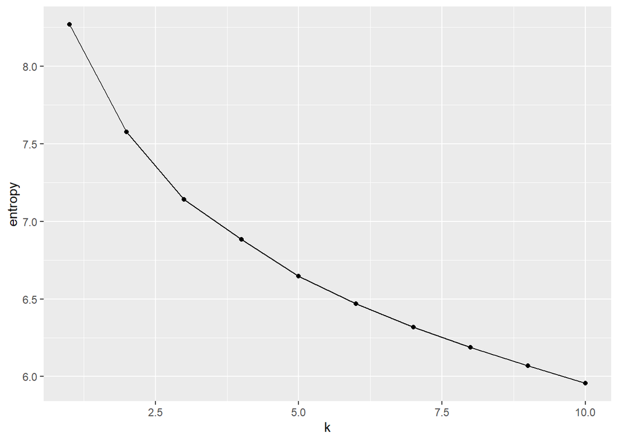

```r
entropy_values <- vector()
for (k in 1:10) {
  kmeans_result <- kmeans(dades[, varNum], centers = k)
  cluster_labels <- kmeans_result$cluster
  cluster_entropy <- sapply(unique(cluster_labels), function(i)
                                entropy::entropy(cluster_labels == i))
  entropy_values[k] <- mean(cluster_entropy)
}

entropy_df <- data.frame(k = 1:10, entropy = entropy_values)
ggplot(entropy_df, aes(x = k, y = entropy)) + geom_point() + geom_line()
```

Puedes buscar una zona donde la entropía disminuya y luego se estabilice, lo que indicaría que aumentar (k) deja de aportar una mejora clara en pureza.

## 3.8 Cophenetic Correlation Coefficient

Mide hasta qué punto el dendrograma reproduce las distancias originales entre observaciones. Un valor cercano a 1 indica una representación jerárquica fiel.

**Mostrar código**

```r
hc_result <- hclust(dist(dades[, varNum]), method = "complete")
cor_coph <- cor(cophenetic(hc_result), dist(dades[, varNum]))
cor_coph
```

```
[1] 0.6083644
```

**Mostrar código**

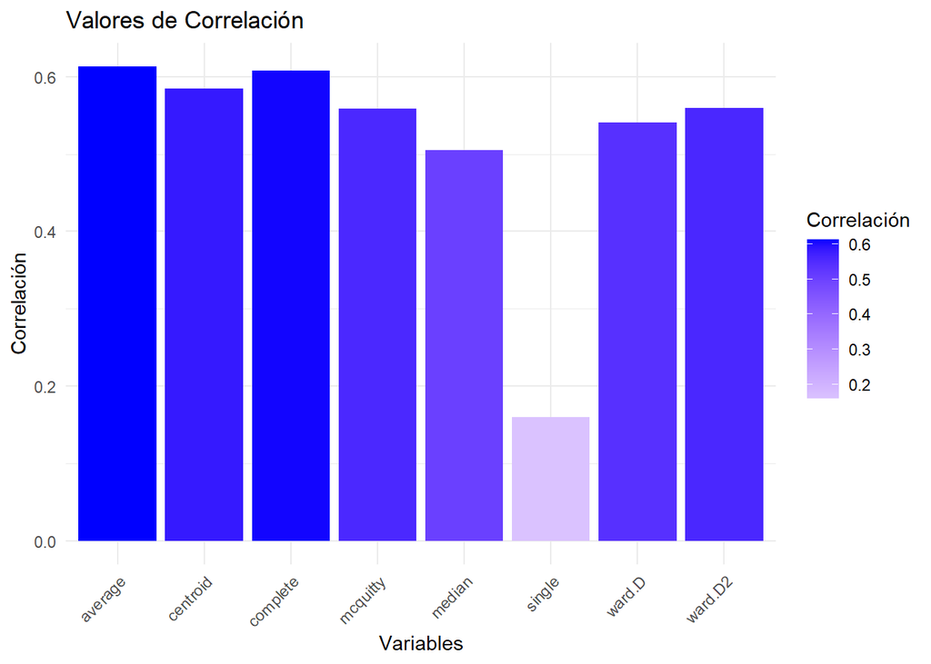

```r
cophen_corr <- c()

metodos <- c("ward.D", "ward.D2", "single", "complete", "average", "mcquitty",
             "median", "centroid")

for (met in metodos) {
  hc_result <- hclust(dist(dades[, varNum]), method = met)
  cophen_corr[met] <- cor(cophenetic(hc_result), dist(dades[, varNum]))
}

df <- data.frame(Nombre = names(cophen_corr), Correlación = cophen_corr)

ggplot(df, aes(x = Nombre, y = Correlación, fill = Correlación)) +
  geom_col() +
  scale_fill_gradient2(low = "red", mid = "white", high = "blue", midpoint = 0) +
  theme_minimal() +
  labs(title = "Valores de Correlación", x = "Variables", y = "Correlación") +
  theme(axis.text.x = element_text(angle = 45, hjust = 1))
```

## 3.9 Coeficiente de correlación ajustado Rand (Adjusted Rand Index)

El ARI mide la similitud entre dos particiones. Es especialmente útil cuando se dispone de etiquetas verdaderas o de una partición de referencia.

**Limitación**

Si no existen etiquetas verdaderas, ARI y AFM no sirven como métricas internas puras. En ese caso deben interpretarse como ejemplos metodológicos o emplearse frente a una partición de referencia externa.

**Mostrar código**

```r
true_labels <- # Etiquetas verdaderas, si las tienes
kmeans_labels <- kmeans_result$cluster
ARI <- mclust::adjustedRandIndex(true_labels, kmeans_labels)
```

Si no tienes etiquetas verdaderas para tus datos, puedes usar la técnica de validación cruzada conocida como “ARI dentro de grupos” (ARI within-cluster).

Para hacerlo, primero debes dividir tus datos en un conjunto de entrenamiento y un conjunto de prueba. Luego, realiza el clustering K-means en el conjunto de entrenamiento y calcula el ARI entre los clusters y las etiquetas verdaderas del conjunto de prueba.

**Mostrar código**

```r
set.seed(123)
training_index <- caret::createDataPartition(datos$clase, p = 0.8, list = FALSE)
training_data <- datos[training_index, ]
test_data <- datos[-training_index, ]

kmeans_result <- kmeans(training_data, centers = 4)
true_labels <- test_data$clase
kmeans_labels <- predict(kmeans_result, test_data)
ARI <- adjustedRandIndex(true_labels, kmeans_labels)
```

El ARI varía entre -1 y 1, donde -1 indica una asignación completamente diferente de los clusters y 1 indica una asignación perfectamente igual de los clusters.

Puedes interpretar el valor del ARI como sigue:

ARI ~ 1: el clustering de alta calidad y se ajusta bien a las etiquetas verdaderas

ARI ~ 0: el clustering de baja calidad y no se ajusta bien a las etiquetas verdaderas

ARI ~ -1: el clustering es peor que una asignación aleatoria de los clusters

**Mostrar código**

```r
ARI_values <- vector()
for (k in 1:10) {
  kmeans_result <- kmeans(datos, centers = k)
  true_labels <- # Etiquetas verdaderas, si las tienes
  kmeans_labels <- kmeans_result$cluster
  ARI <- adjustedRandIndex(true_labels, kmeans_labels)
  ARI_values <- c(ARI_values, ARI)
}

plot(ARI_values ~ 1:10, type = "b", xlab = "Número de clusters (k)", ylab = "ARI")
```

Para decidir el número de clusters adecuado, debemos buscar el valor de (k) que maximice el ARI.

## 3.10 Coeficiente de correlación ajustado Fowlkes-Mallows (Adjusted Fowlkes-Mallows Index)

El índice de Fowlkes-Mallows ajustado también mide similitud entre particiones y puede interpretarse como una alternativa al ARI cuando interesa evaluar coincidencia entre pares de observaciones agrupadas.

**Mostrar código**

```r
true_labels <- # Etiquetas verdaderas, si las tienes

# Calcula el AFM
AFM <- clevr::fowlkes_mallows(true_labels, clustering$cluster)

# Muestra el valor de AFM
print(AFM)
```

**Mostrar código**

```r
AFM_values <- vector()
for (k in 1:10) {
  kmeans_result <- kmeans(datos, centers = k)
  true_labels <- # Etiquetas verdaderas, si las tienes
  kmeans_labels <- kmeans_result$cluster
  AFM <- clevr::fowlkes_mallows(true_labels, kmeans_labels)
  AFM_values <- c(AFM_values, AFM)
}

plot(AFM_values ~ 1:10, type = "b", xlab = "Número de clusters (k)", ylab = "AFM")
```

Para decidir el número de clusters adecuado, debemos buscar el valor de (k) que maximice el AFM.

## 3.11 Error de reconstrucción

Esta métrica mide la diferencia entre la distancia original entre los objetos y la distancia entre los clusters en el dendrograma. Un valor cercano a 0 indica una buena representación de los datos en el árbol jerárquico.

**Mostrar código**

```r
hc_result <- hclust(dist_matrix, method = "complete")
error_reconstr <- sum((dist_matrix - as.dist(as.matrix(cophenetic(hc_result))))^2)
```

**Mostrar código**

```r
error_reconstr <- c()
for (k in 2:10) {
  hc_result <- hclust(dist_matrix, method = "complete")
  error_reconstr[k-1] <- sum((dist_matrix - as.dist(as.matrix(cophenetic(hc_result))))^2)
}
plot(error_reconstr, type="b", xlab="Number of clusters", ylab="Error de reconstrucción")
```

## 3.12 Cálculo de los estadísticos para todos los valores de K buscados

Cuando se desea una evaluación más global, puede automatizarse el cálculo de múltiples índices sobre un rango de valores de (k).

**Mostrar código**

```r
info <- NbClust::NbClust(data = dades[, varNum], distance = "euclidean",
                         min.nc = 3, max.nc = 10, method = "ward.D2")
```

Otra forma seria usando la libreria `fpc`.

**Mostrar código**

```r
fpc::clusterbenchstats
```

# 4 Bibliografia

- https://www.datanovia.com/en/lessons/determining-the-optimal-number-of-clusters-3-must-know-methods/

Aquesta web està creada por Dante Conti y Sergi Ramírez, (c) 2026